# Лабораторная работа №3

## Локальный поиск

#### *Выполнил: Сарнацкий Владислав*

#### *Группа: ІП-71мн*

*Цель работы:* Рассмотреть алгоритмы локального поиска для решение задач оптимизации.

Всякие нужные импорты

```python
import numpy as np
import matplotlib.pyplot as plt
import seaborn as sns
import pandas as pd
```

Импортируем состояния **EightPuzzleState**, алгоритмы **BFS, LDFS, IDS, RBFS, A_star** из второй лабораторной работы и алгоритмы **ANNEAL, BEAM**.

```python
from lab2_problems import EightPuzzleState
from lab2_algs import BFS, LDFS, IDS, RBFS, A_star
from lab3_algs import ANNEAL, BEAM
```

Протестируем алгоритм имитации отжига на задаче "игры в 8". За начальное состояние доски возьмем целевое состояние и сделаем несколько "худших" согласно метрике "h1" ходов. Количество ходов возьмем из списка {1, 3, 5, 7, 9}.

```python
res = []
for swaps in [1, 3, 5, 7, 9]:
    for test in range(50):
        s = EightPuzzleState().random_state(swaps)
        done, iters, time = ANNEAL(s, 'h1', 10000)
        res.append(['ANNEAL', 'LOC', 'H1', swaps, iters, time, done])

        done, iters, time = ANNEAL(s, 'h2', 10000)
        res.append(['ANNEAL', 'LOC', 'H2', swaps, iters, time, done])

df = pd.DataFrame(res, columns=['Algorithm', 'Alg type', 'Heuristic', 'Swaps', 'Iterations', 'Execution time', 'Done'])
```

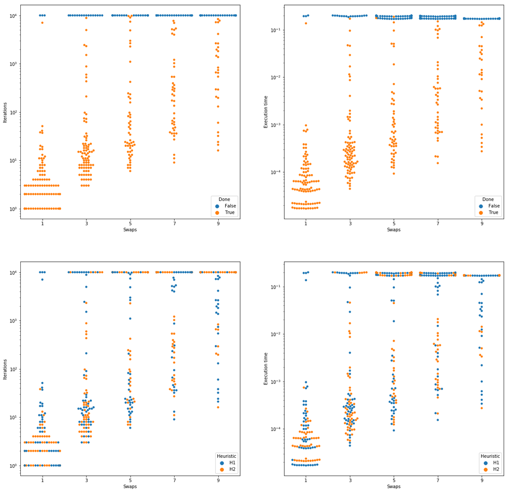

```python
f, ax = plt.subplots(ncols=2, nrows=2, figsize=(20, 20))
ax[0, 0].set(yscale='log')
ax[0, 1].set(yscale='log')
ax[1, 0].set(yscale='log')
ax[1, 1].set(yscale='log')

sns.swarmplot(y="Iterations", x="Swaps", hue="Done",
              data=df,
              zorder=1, ax=ax[0, 0])
sns.swarmplot(y="Execution time", x="Swaps", hue="Done",
              data=df,
              zorder=1, ax=ax[0, 1])
sns.swarmplot(y="Iterations", x="Swaps", hue="Heuristic",
              data=df,
              zorder=1, ax=ax[1, 0])
sns.swarmplot(y="Execution time", x="Swaps", hue="Heuristic",
              data=df,
              zorder=1, ax=ax[1, 1])
plt.show()
```

Как можно заметить эффетивность алгоритма резко падает с увеличением количества начальных ходов.

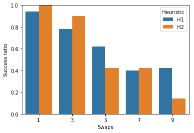

```python
df_temp = pd.DataFrame(df.groupby(['Swaps', 'Heuristic'], as_index=False)[['Done']].mean())
fix, ax = plt.subplots()
sns.barplot(x='Swaps', y='Done', hue='Heuristic', data=df_temp, ax=ax)
ax.set_ylabel('Success ratio')
ax.set_ylim([0, 1])
plt.show()
```

Протестируем работу локального лучевого поиска.

```python
res = []
for swaps in [1, 3, 5, 7, 9]:
    for beams in [2, 5, 10, 15, 21]:
        for test in range(50):
            s = EightPuzzleState().random_state(swaps)
            done, iters, time = BEAM(s, 'h1', beams, 100)
            res.append(['BEAM', 'LOC', 'H1', swaps, beams, iters, time, done])

            done, iters, time = BEAM(s, 'h2', beams, 100)
            res.append(['BEAM', 'LOC', 'H2', swaps, beams, iters, time, done])

df = pd.DataFrame(res, columns=['Algorithm', 'Alg type', 'Heuristic', 'Swaps', 'Beams', 'Iterations', 'Execution time', 'Done'])
```

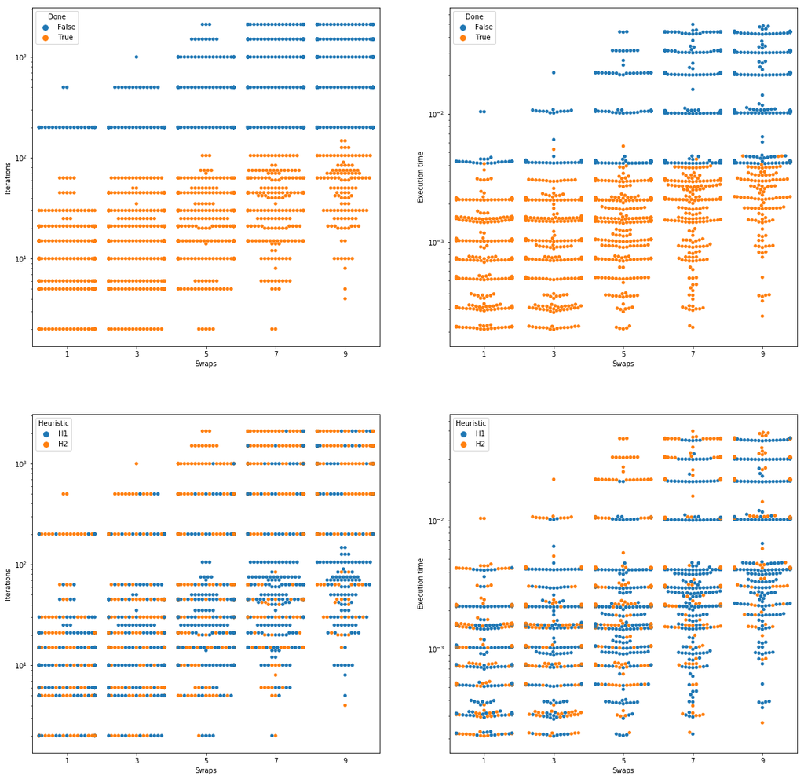

```python
f, ax = plt.subplots(ncols=2, nrows=2, figsize=(20, 20))
ax[0, 0].set(yscale='log')
ax[0, 1].set(yscale='log')
ax[1, 0].set(yscale='log')
ax[1, 1].set(yscale='log')

sns.swarmplot(y="Iterations", x="Swaps", hue="Done",
              data=df,
              zorder=1, ax=ax[0, 0])
sns.swarmplot(y="Execution time", x="Swaps", hue="Done",
              data=df,
              zorder=1, ax=ax[0, 1])
sns.swarmplot(y="Iterations", x="Swaps", hue="Heuristic",
              data=df,
              zorder=1, ax=ax[1, 0])
sns.swarmplot(y="Execution time", x="Swaps", hue="Heuristic",
              data=df,
              zorder=1, ax=ax[1, 1])
plt.show()
```

Графики выше показывают вполне ожидаемые рузьтаты.